# ISYE 6402 Homework 6 Template

## Background

Individuals stock prices tend to exhibit high amounts of non-constant variance, and thus ARIMA models build upon that data would likely exhibit non-constant variance in residuals. In this problem we are going to analyze the Tesla stock price data from 2011 through end of July 2021. We will use the ARIMA-GARCH to model daily and weekly stock price (adjusted close price at the end of a day for daily data or at the end of the week for weekly data), with a focus on the behavior of its volatility as well as forecasting both the price and the volatility.

##Data import and cleaning

```r
## Libraries used within this homework are uploaded here
library(zoo,warn.conflicts=FALSE)
library(lubridate,warn.conflicts=FALSE)
library(mgcv,warn.conflicts=FALSE)
library(rugarch,warn.conflicts=FALSE)
```

```r
#importing the data
dailydata <- read.csv("C:/Users/19807/Desktop/DailyTSLA.csv", head = TRUE)
weeklydata <- read.csv("C:/Users/19807/Desktop/WeeklyTSLA.csv", head = TRUE)

#cleaning the data

#dates to date format
weeklydata$Date<-as.Date(weeklydata$Date,format='%m/%d/%Y')
dailydata$Date<-as.Date(dailydata$Date,format='%m/%d/%Y')

#prices to timeseries format
TSLAWeekly <- ts(weeklydata$Adj.Close,start=c(2011,1,1),freq=52)
TSLADaily <- ts(dailydata$Adj.Close,start=c(2011,1,1),freq=252)
```

#Question 1: Exploratory Data Analysis (20 points)

**1a.** Based on your intuition, when would you use daily vs weekly stock price data? Response: As stock price fluctuates by seconds, usually when looking for a short-term trading or day trading, I would look at the price variation within a shorter term to time in the market; while when looking for long term investment, analyzing the weekly stock price is computationally less expensive and makes more sense to examine the trend. In sum, when doing a shorter term/day trading, I would look at the daily stock price; when investing for longer term, swing trading or long term investing, I would look at the weekly price data.

**1b.** Plot the time series plots comparing daily vs weekly data. How do the daily vs weekly time series data compare?

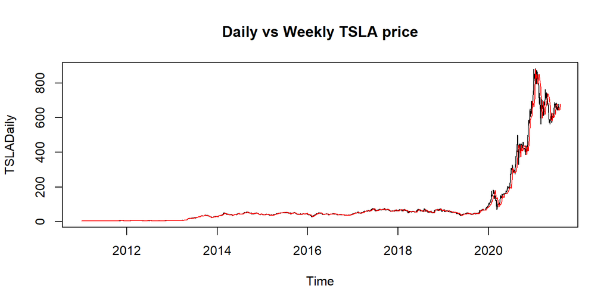

```r
par(mfrow=c(1,1))
ts.plot(TSLADaily, main="Daily vs Weekly TSLA price")
lines(TSLAWeekly,col="red")
```

*Response: Weekly vs Montly Time Series data comparison* The daily price is more volatile than the weekly price data, especially after 2020. In year of 2020, We saw several deeper dips and sharper increases in TESLA daily price than those in weekly price. Prior to 2020, there’s not much difference as TESLA price overall was not as volatile as it turned to be after 2020. We can tell the more volatile the stovk is, the more precise the daily price can capture its trend.

**1c.** Fit a non-parametric trend using splines regression to both the daily and weekly time series data. Overlay the fitted trends. How do the trends compare?

*Analyzing weekly and daily data with trend fitting*

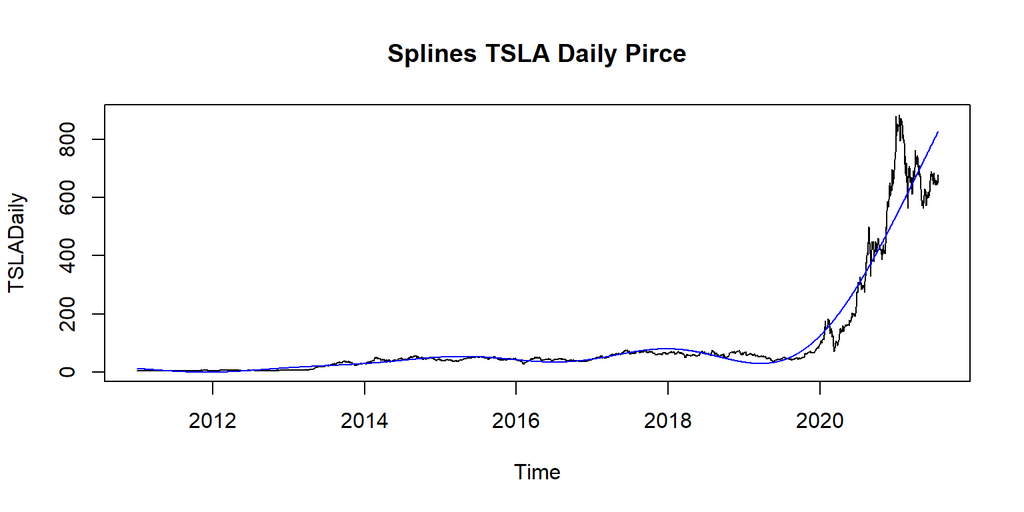

```r
#daily
time.points.d= c(1:length(TSLADaily))
time.points.d=c(time.points.d-min(time.points.d))/max(time.points.d)
gam.daily=gam(TSLADaily~s(time.points.d))
gam.fit.daily =ts(fitted(gam.daily),start=c(2011,1,1),freq=252)
ts.plot(TSLADaily,main="Splines TSLA Daily Pirce")
lines(gam.fit.daily,col="blue")
```

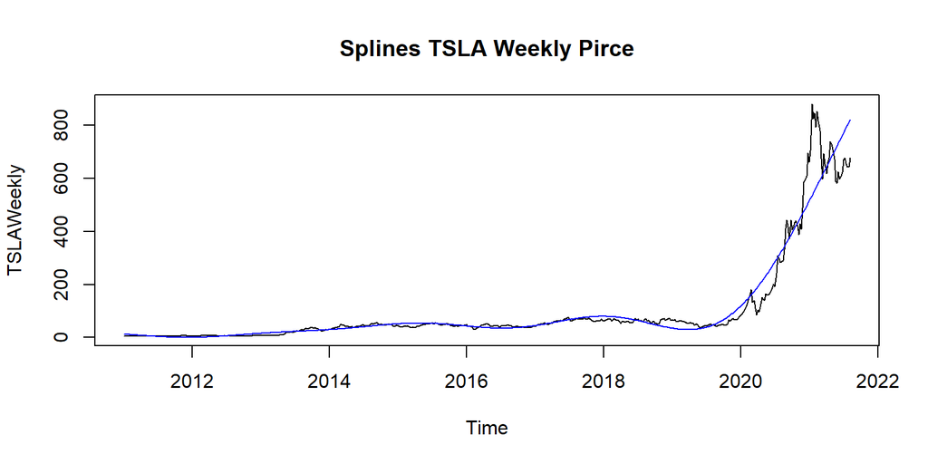

```r
#weekly
time.points.W= c(1:length(TSLAWeekly))
time.points.W=c(time.points.W-min(time.points.W))/max(time.points.W)
gam.weekly=gam(TSLAWeekly~s(time.points.W))
gam.fit.weekly =ts(fitted(gam.weekly),start=c(2011,1,1),freq=52)
ts.plot(TSLAWeekly,main="Splines TSLA Weekly Pirce")
lines(gam.fit.weekly,col="blue")
```

**1d.** Consider the return stock price computed as provided in the canvas homework assignment. Apply this formula to compute the return price based on the daily and weekly time series data. Plot the return time series and their corresponding ACF plots. How do the return time series compare in terms of stationarity and serial dependence?

*Analyzing weekly and daily return data and comparing with original data*

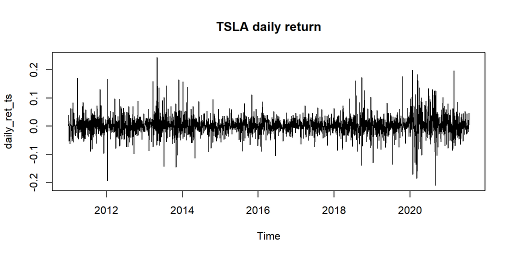

```r
#daily
daily_prices <- dailydata[, "Adj.Close", drop = FALSE]
n <- nrow(dailydata)
daily_ret <- ((daily_prices[2:n, 1] - daily_prices[1:(n - 1), 1])/daily_prices[1:(n - 1), 1])
names(daily_ret) <- daily_prices[2:n, 1]
daily_ret_ts = ts(daily_ret,start=c(2011,1,1),freq=252)
ts.plot(daily_ret_ts,main="TSLA daily return")
```

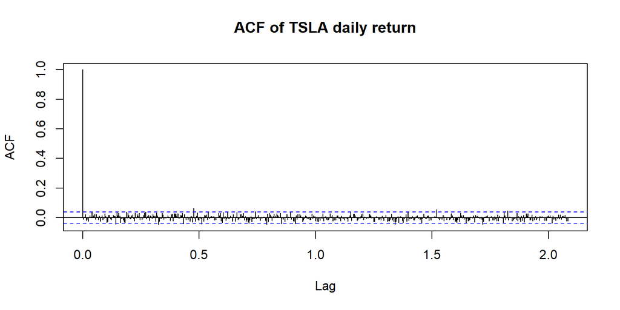

```r
acf(daily_ret_ts,lag.max=525, main="ACF of TSLA daily return")
```

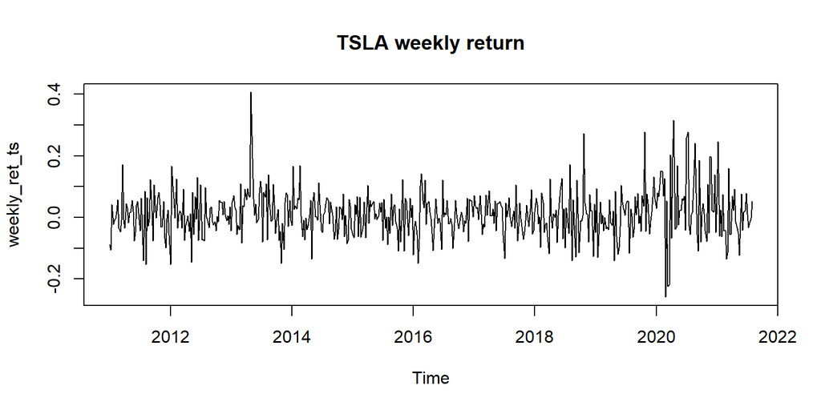

```r
#weekly
weekly_prices <- weeklydata[, "Adj.Close", drop = FALSE]
n <- nrow(weekly_prices)
weekly_ret <- ((weekly_prices[2:n, 1] - weekly_prices[1:(n - 1), 1])/weekly_prices[1:(n - 1), 1])
names(weekly_ret) <- weekly_prices[2:n, 1]
weekly_ret_ts = ts(weekly_ret,start=c(2011,1,1),freq=52)
ts.plot(weekly_ret_ts,main="TSLA weekly return")
```

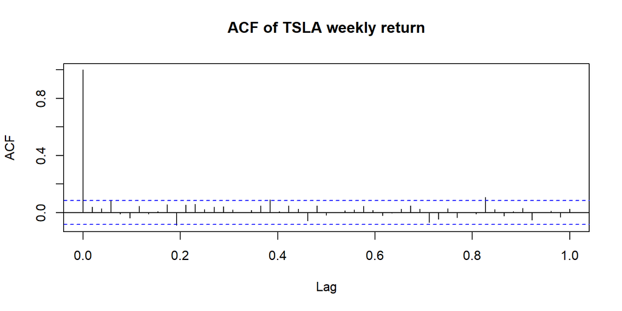

```r
acf(weekly_ret_ts,lag.max=52, main="ACF of TSLA weekly return")
```

#Question 2: ARIMA(p,d,q) for Stock Price (20 Points)

**2a.** Divide the data into training and testing data set, where the training data exclude the last week of data (July 26th-July 30th) with the testing data including the last week of data. Apply the iterative model to fit an ARIMA(p,d,q) model with max AR and MA orders of 8 and difference orders 1 and 2 separately to the training datasets of the daily and weekly data. Display the summary of the final model fit.

```r
#daily
n=length(TSLADaily)
nforward=4
nfit=n-nforward
train.daily=TSLADaily[1:nfit]
test.daily=TSLADaily[(nfit+1):n]
#Fitting ARIMA model
  final.aic=Inf
    final.order=c(0,0,0)
    for (p in 0:8) for (d in 1:2) for (q in 0:8)
    {
        current.aic=AIC(arima(train.daily,order=c(p, d, q),method="ML"))
        if(current.aic<final.aic)
        {
            final.aic=current.aic
            final.order=c(p,d,q)
            final.arima=arima(train.daily, order=final.order,method="ML")
        }
    }

    # What is the selected order?
    final.order
```

```
## [1] 8 1 7
```

```r
#weekly
n=length(TSLAWeekly)
nforward=1
nfit=n-nforward
train.weekly = TSLAWeekly[1:nfit]
test.weekly = TSLAWeekly[(nfit+1):n]
#Fitting ARIMA model
  final.aic=Inf
    final.order=c(0,0,0)
    for (p in 0:8) for (d in 1:2) for (q in 0:8)
    {
        current.aic=AIC(arima(TSLAWeekly,order=c(p, d, q), method="ML"))
        if(current.aic<final.aic)
        {
            final.aic=current.aic
            final.order=c(p,d,q)
            final.arima=arima(TSLAWeekly, order=final.order, method="ML")
        }
    }

    # What is the selected order?
    final.order
```

```
## [1] 8 2 8
```

```r
modarima.daily=arima(train.daily,order=c(8,1,7),method="ML")
modarima.daily
```

```
##
## Call:
## arima(x = train.daily, order = c(8, 1, 7), method = "ML")
##
## Coefficients:
##           ar1     ar2     ar3      ar4      ar5     ar6     ar7     ar8     ma1
##       -0.5348  0.0227  0.6483  -0.7204  -0.4372  0.1284  0.7808  0.2093  0.4636
## s.e.   0.0615  0.0668  0.0640   0.0261   0.0661  0.0666  0.0591  0.0226  0.0605
##           ma2      ma3     ma4     ma5      ma6      ma7
##       -0.0775  -0.5825  0.8738  0.3379  -0.2111  -0.6979
## s.e.   0.0717   0.0668  0.0190  0.0664   0.0705   0.0591
##
## sigma^2 estimated as 54.77:  log likelihood = -9087.18,  aic = 18206.36
```

```r
modarima.weekly=arima(train.weekly,order=c(8,2,8),method="ML")
modarima.weekly
```

```
##
## Call:
## arima(x = train.weekly, order = c(8, 2, 8), method = "ML")
##
## Coefficients:
##           ar1      ar2      ar3     ar4     ar5     ar6     ar7      ar8
##       -0.6769  -0.4159  -0.4338  0.4373  0.3472  0.6367  0.6538  -0.1089
## s.e.      NaN      NaN      NaN     NaN     NaN     NaN  0.0530   0.0472
##           ma1      ma2     ma3      ma4     ma5      ma6      ma7     ma8
##       -0.2396  -0.3371  0.2494  -1.0133  0.0776  -0.3090  -0.3067  0.8856
## s.e.      NaN      NaN  0.0416   0.0268  0.0297   0.0326      NaN     NaN
##
## sigma^2 estimated as 234.8:  log likelihood = -2286.2,  aic = 4606.41
```

*Response: Analysis of the ARIMA Fit for the Weekly and daily Data* ARIMA of daily return, we select the order ARIMA(8,1,7) with AIC=18206.36. It requires 1 order difference with AR(8) coefficient and MA(7)coefficient. The estimate of the variance is 54.77. It is large so showing ARIMA might not be a good fit for forecasting the daily trend . ARIMA of weekly return, we select the order ARIMA(8,2,8) with AIC= 4606.41.It requires 2 order differences with AR(8) coefficient and MA(8)coefficient. The estimate of the variance is 234.8. It is also too large to support that ARIMA(8,2,8) is a good fit to forecast the trend.

**2b.** Evaluate the model residuals and squared residuals using the ACF and PACF plots as well as hypothesis testing for serial correlation. What would you conclude based on this analysis?

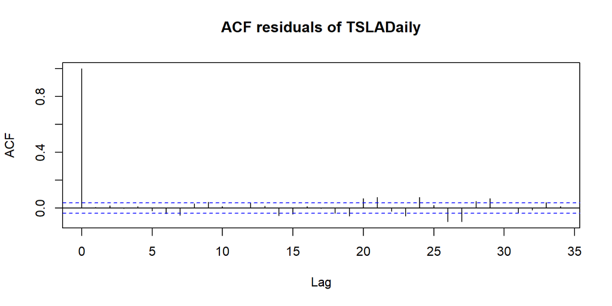

```r
#daily
porderD=8
qorderD=7
resid=resid(modarima.daily)
resid.squred=resid^2

acf(resid,main="ACF residuals of TSLADaily")
```

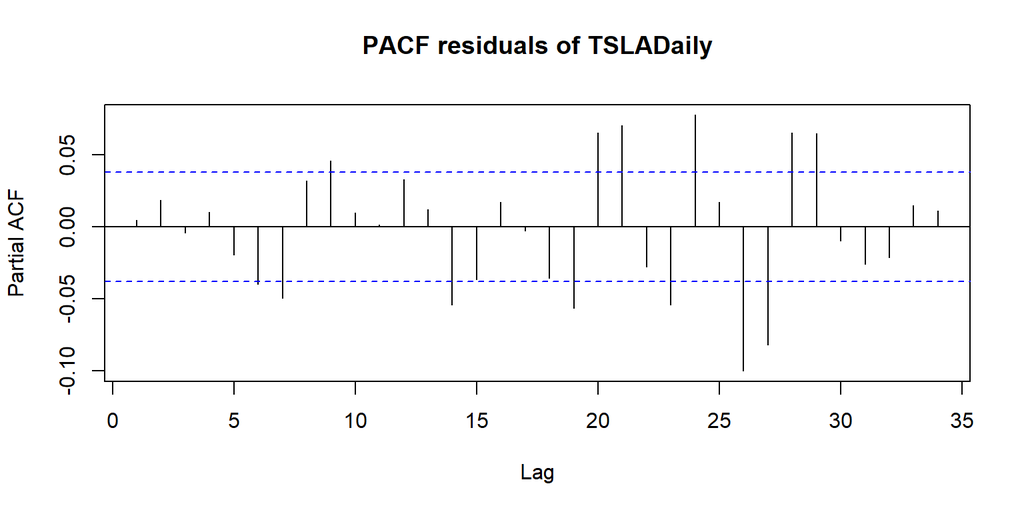

```r
pacf(resid,main="PACF residuals of TSLADaily")
```

```r
Box.test(resid,lag=(porderD+qorderD+1),type="Ljung",fitdf=(porderD+qorderD))
```

```
##
##  Box-Ljung test
##
## data:  resid
## X-squared = 38.189, df = 1, p-value = 6.42e-10
```

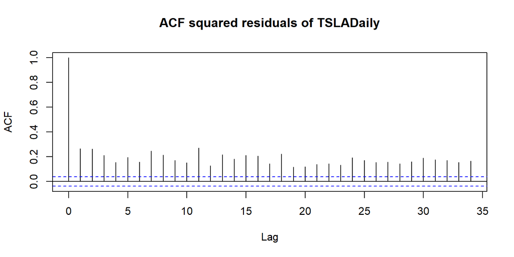

```r
acf(resid.squred,main="ACF squared residuals of TSLADaily")
```

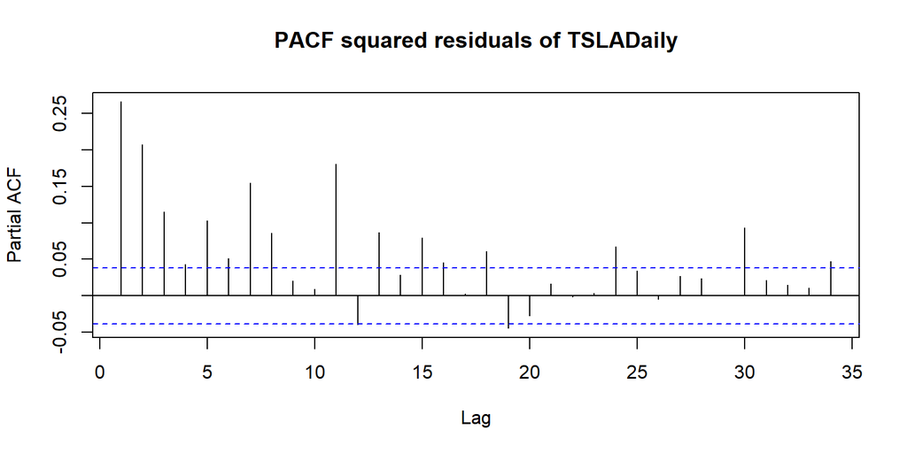

```r
pacf(resid.squred,main="PACF squared residuals of TSLADaily")
```

```r
Box.test(resid.squred,lag=(porderD+qorderD+1),type="Ljung",fitdf=(porderD+qorderD))
```

```
##
##  Box-Ljung test
##
## data:  resid.squred
## X-squared = 1834.9, df = 1, p-value < 2.2e-16
```

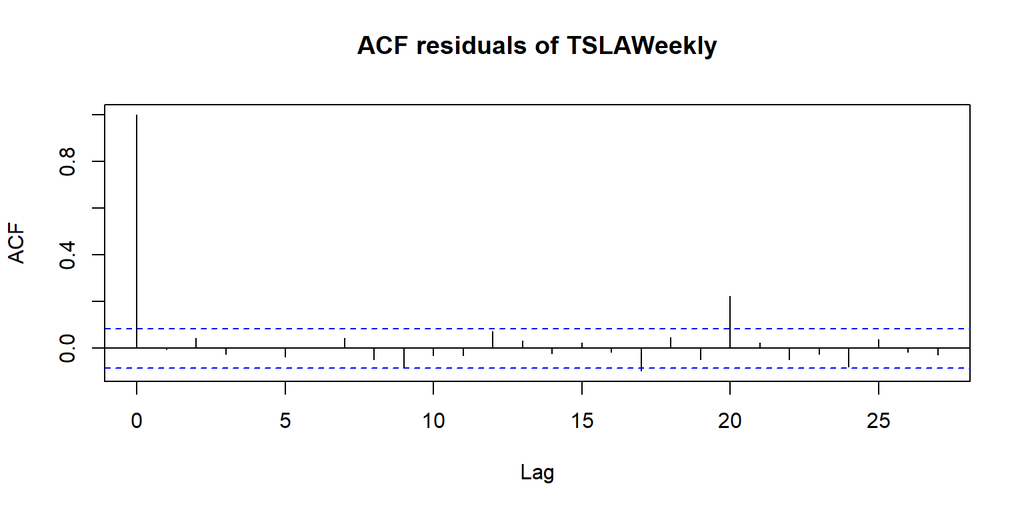

```r
#weekly
porderw=8
qorderw=8
wresid=resid(modarima.weekly)
wresid.squred=resid^2

acf(wresid,main="ACF residuals of TSLAWeekly")
```

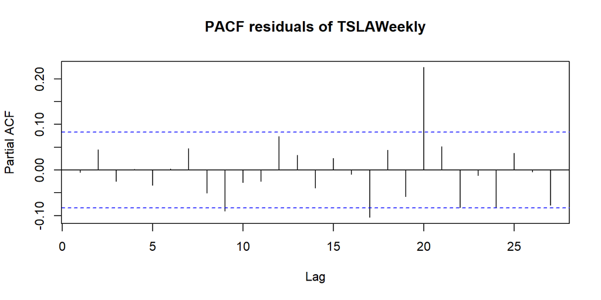

```r
pacf(wresid,main="PACF residuals of TSLAWeekly")
```

```r
Box.test(wresid,lag=(porderw+qorderw+1),type="Ljung",fitdf=(porderw+qorderw))
```

```
##
##  Box-Ljung test
##
## data:  wresid
## X-squared = 19.386, df = 1, p-value = 1.068e-05
```

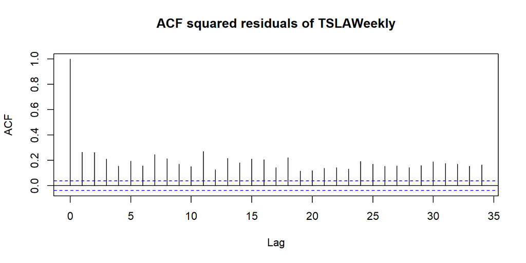

```r
acf(wresid.squred,main="ACF squared residuals of TSLAWeekly")
```

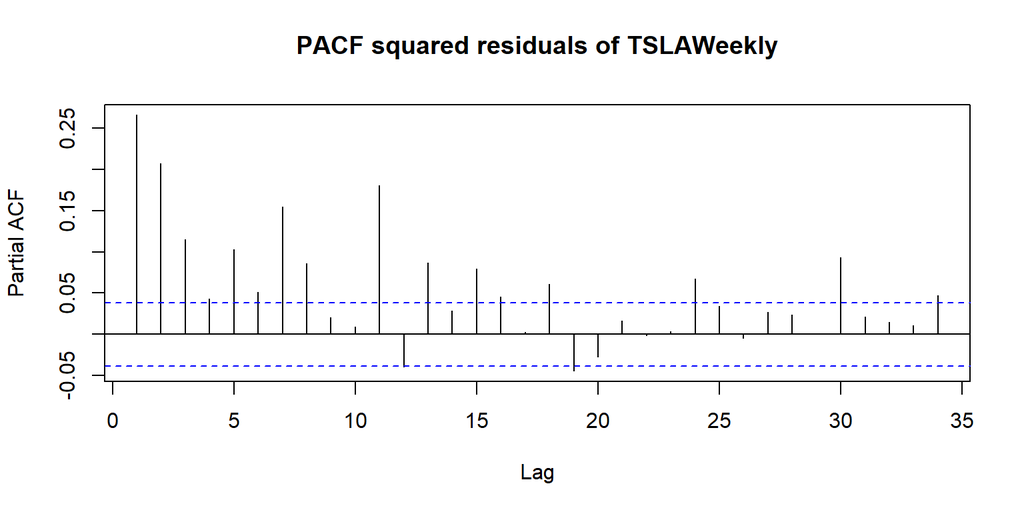

```r
pacf(wresid.squred,main="PACF squared residuals of TSLAWeekly")
```

```r
Box.test(wresid.squred,lag=(porderw+qorderw+1),type="Ljung",fitdf=(porderw+qorderw))
```

```
##
##  Box-Ljung test
##
## data:  wresid.squred
## X-squared = 1891.1, df = 1, p-value < 2.2e-16
```

*Response:ARIMA residual analysis for the Weekly and daily Data* The daily ARIMA residual plot shows no pattern, the variance of the residual is not constant.The residual ACF plot has multiple lags such as 7,14,21,28 that are beyond the confidence band; so did the residual PACF plot. The squared residual plot shows corrected and dependent, its ACF plot also shows a cyclical pattern. The weekly ARIMA plot demonstrates similar results: the residual plot violates stationarity as there are lags beyond the confidence band. The ACF pf the squared residuals shows a cyclical pattern. The p values are small indicating correlated residuals. Overall, the residual analysis show small P value which accept the correlation of the residuals, which is not ideal. We usually want to see the uncorrelated residuals (P value is large). So we may look for another model that fits the data better. **2c.** Apply the model identified in (2a) and forecast the last week of data. Plot the predicted data to compare the predicted values to the actual observed ones. Include 95% confidence intervals for the forecasts in the corresponding plots.

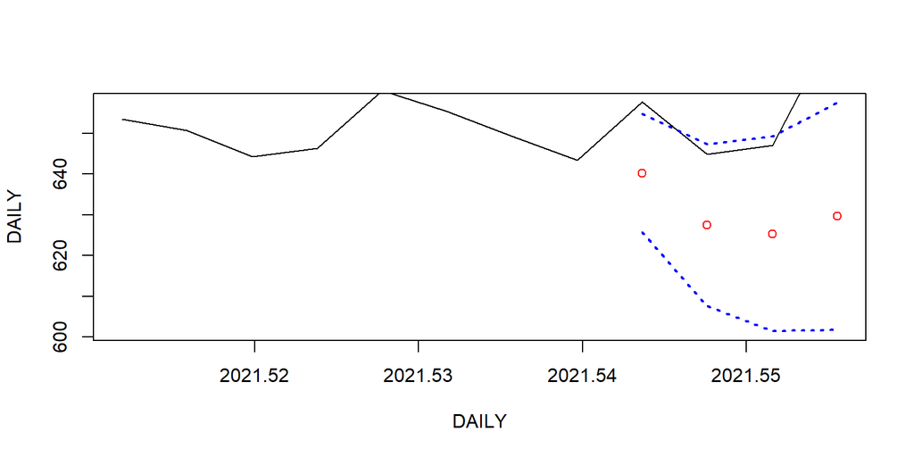

```r
#Daily prediction
#95% = 1.965

outpredD <- predict(modarima.daily, n.ahead = 4)

uboundD <- outpredD$pred + 1.965 * outpredD$se
lboundD <- outpredD$pred - 1.965 * outpredD$se
ymin <- min(lboundD)
ymax <- max(uboundD)
daily <- index(TSLADaily)
par(mfrow = c(1, 1))
plot(daily[2650:2661], TSLADaily[2650:2661],
type = "l", ylim = c(ymin, ymax), xlab = "DAILY", ylab = "DAILY")
points(daily[2658:2661], outpredD$pred, col = "red")
lines(daily[2658:2661], uboundD,lty = 3, lwd = 2, col = "blue")
lines(daily[2658:2661], lboundD,lty = 3, lwd = 2, col = "blue")
```

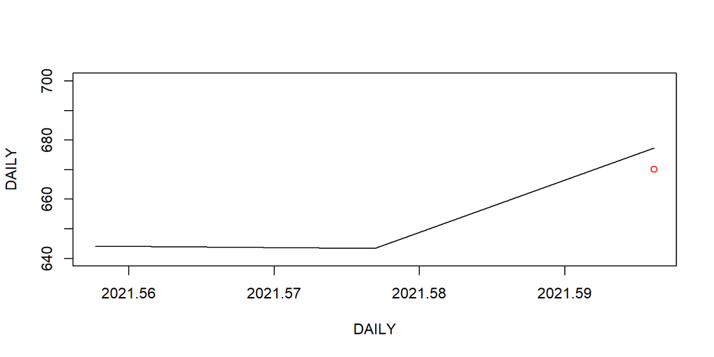

```r
#weekly prediction
#95% = 1.965

outpredw <- predict(modarima.weekly, n.ahead = 1)

uboundw <- outpredw$pred + 1.965 * outpredw$se
lboundw <- outpredw$pred - 1.965 * outpredw$se
ymin <- min(lboundw)
ymax <- max(uboundw)
weekly <- index(TSLAWeekly)
par(mfrow = c(1, 1))
plot(weekly[550:552], TSLAWeekly[550:552],
type = "l", ylim = c(ymin, ymax), xlab = "DAILY", ylab = "DAILY")
points(weekly[552:552], outpredw$pred, col = "red")
lines(weekly[552:552], uboundw,lty = 3, lwd = 2, col = "blue")
lines(weekly[552:552], lboundw,lty = 3, lwd = 2, col = "blue")
```

*Response: Predictions* Daily： when overlaying he predicted value in red with the actual value in black, we see the predicted value is smaller than the actual values. Even the predicted values are all within the 95% confidence value(in blue), some of the actual values are beyond the the 95% confidence value showing it is not a precise prediction. Weekly：The observed value is within the confidence bands but the predicted value is slightly lower than the actual value.

**2d.** Calculate Mean Absolute Percentage Error (MAPE) and Precision Measure (PM). How many observations are within the prediction bands? Compare the accuracy of the predictions for the daily and weekly time series using these two measures.

```r
actual.daily = test.daily
predict.daily= outpredD$pred
mean(abs(predict.daily-actual.daily)/actual.daily)
```

```
## [1] 0.03933095
```

```r
sum((predict.daily-actual.daily)^2)/sum((actual.daily-mean(actual.daily))^2)
```

```
## [1] 5.046332
```

```r
actual.weekly = test.weekly
predict.weekly= outpredw$pred
mean(abs(predict.weekly-actual.weekly)/actual.weekly)
```

```
## [1] 0.01070396
```

```r
sum((predict.weekly-actual.weekly)^2)/sum((actual.weekly-mean(actual.weekly))^2)
```

```
## [1] Inf
```

*Response: Prediction Comparison* For MAPE, the lower the better. Daily MAPE is 0.039, while weekly MAPE is 0.01; this shows that weekly prediction is more accurate than the daily prediction. Since MAPE is commonly used but not appropriate to evaluate prediction accuracy for most time serie models, here to look at the PM. PM measures the proportion between the variability in the prediction and the variability in the test data; and the lower the better ; hence the daily PM of 5.04 shows poor prediction. As there’s only one prediction in weekly data, we are unable to calculate the PM.

#Question 3: ARMA(p,q)-GARCH(m,n) for Return Stock Price (20 Points)

**3a.** Divide the data into training and testing data set, where the training data exclude the last week of data (July 26th-July 30th) with the testing data including the last week of data. Apply the iterative model to fit an ARMA(p,q)-GARCH(m,n) model by selecting the orders for p & q up to 5 and orders for m & n up to 2. Display the summary of the final model fit. Write up the equation of the estimated model.

```r
#Daily
n=length(daily_ret_ts)
n_forward=4
nfit=n-n_forward
train.dailyR=daily_ret_ts[1:nfit]
test.dailyR=daily_ret_ts[(nfit+1):n]

test_model <- function(p,d,q){
  #TSLADaily
  mod = arima(train.dailyR, order=c(p,d,q), method="ML")
  current.aic = AIC(mod)
  df = data.frame(p,d,q,current.aic)
  names(df) <- c("p","d","q","AIC")
  return(df)
}

orders = data.frame(Inf,Inf,Inf,Inf)
names(orders) <- c("p","d","q","AIC")


for (p in 0:5){
  for (d in 0:0){
    for (q in 0:5) {
      possibleError <- tryCatch(
        orders<-rbind(orders,test_model(p,d,q)),
        error=function(e) e
      )
      if(inherits(possibleError, "error")) next

    }
  }
 }
orders <- orders[order(-orders$AIC),]
tail(orders)
```

```
##    p d q       AIC
## 9  1 0 1 -10266.92
## 14 2 0 0 -10267.01
## 4  0 0 2 -10267.03
## 3  0 0 1 -10268.91
## 8  1 0 0 -10268.92
## 2  0 0 0 -10270.69
```

```r
#GARCH Model
    library(rugarch)
        #Select model with smallest BIC (if prediction is the objective)
            final.bic = Inf
            final.order = c(0,0)
            for (p in 0:2) for (q in 0:2)
            {
                spec = ugarchspec(variance.model=list(garchOrder=c(p,q)),
                mean.model=list(armaOrder=c(1, 0), include.mean=T),
                distribution.model="std")
                fit = ugarchfit(spec, train.dailyR, solver = 'hybrid')
                current.bic = infocriteria(fit)[2]
                if (current.bic < final.bic)
                {
                    final.bic = current.bic
                    final.order = c(p, q)
                }
            }
        final.order
```

```
## [1] 1 1
```

m=1,n=1

```r
   #Refine the ARMA order
test_model2 <- function(p,q){
spec = ugarchspec(variance.model=list(garchOrder=c(1,1)),
mean.model=list(armaOrder=c(p,q),
include.mean=T),
distribution.model="std")
fit = ugarchfit(spec, train.dailyR, solver = 'hybrid')
current.bic = infocriteria(fit)[2]
df = data.frame(p,q,current.bic)
names(df) <- c("p","q","BIC")
return(df)
}

orders2 = data.frame(Inf,Inf,Inf)
names(orders2) <- c("p","q","BIC")
for (p in 0:5){
for (q in 0:5){
possibleError <- tryCatch(
orders2<-rbind(orders2,test_model2(p,q)),
error=function(e) e
)
if(inherits(possibleError, "error")) next
}
}
orders2 <- orders2[order(-orders2$BIC),]
tail(orders2)
```

```
##    p q       BIC
## 14 2 0 -4.143933
## 4  0 2 -4.143934
## 9  1 1 -4.144117
## 8  1 0 -4.146882
## 3  0 1 -4.146883
## 2  0 0 -4.149811
```

```r
#Refine the GARCH order
        final.bic = Inf
        final.order.garch = c(0,1)
        for (p in 0:2) for (q in 0:2)
        {
            spec = ugarchspec(variance.model=list(garchOrder=c(p,q)),
            mean.model=list(armaOrder=c(0,1),
                include.mean=T), distribution.model="std")
                fit = ugarchfit(spec,train.dailyR, solver = 'hybrid')
                current.bic = infocriteria(fit)[2]
                if (current.bic < final.bic)
            {
                final.bic = current.bic
                final.order.garch = c(p, q)
                }
               }
        final.order.garch
```

```
## [1] 1 1
```

```r
n=length(daily_ret_ts)
n_forward=4
nfit=n-n_forward
train.dailyR=daily_ret_ts[1:nfit]
test.dailyR=daily_ret_ts[(nfit+1):n]
library(fGarch)
spec.1 = ugarchspec(variance.model=list(garchOrder=c(1,1)),
            mean.model=list(armaOrder=c(0,1),
            include.mean=T), distribution.model="std")
        final.model.Daily = ugarchfit(spec.1, train.dailyR, solver = 'hybrid')
final.model.Daily
```

```
##
## *---------------------------------*
## *          GARCH Model Fit        *
## *---------------------------------*
##
## Conditional Variance Dynamics
## -----------------------------------
## GARCH Model  : sGARCH(1,1)
## Mean Model   : ARFIMA(0,0,1)
## Distribution : std
##
## Optimal Parameters
## ------------------------------------
##         Estimate  Std. Error   t value Pr(>|t|)
## mu      0.001373    0.000492   2.79176 0.005242
## ma1    -0.005690    0.017448  -0.32613 0.744326
## omega   0.000013    0.000002   5.17446 0.000000
## alpha1  0.034656    0.004398   7.87965 0.000000
## beta1   0.957611    0.002668 358.91266 0.000000
## shape   3.558359    0.217710  16.34451 0.000000
##
## Robust Standard Errors:
##         Estimate  Std. Error   t value Pr(>|t|)
## mu      0.001373    0.000479   2.86532 0.004166
## ma1    -0.005690    0.016053  -0.35446 0.722991
## omega   0.000013    0.000004   2.99325 0.002760
## alpha1  0.034656    0.007213   4.80458 0.000002
## beta1   0.957611    0.001251 765.33375 0.000000
## shape   3.558359    0.250487  14.20575 0.000000
##
## LogLikelihood : 5530.714
##
## Information Criteria
## ------------------------------------
##
## Akaike       -4.1602
## Bayes        -4.1469
## Shibata      -4.1602
## Hannan-Quinn -4.1554
##
```

[output cut: 43 more lines]

```
## Negative Sign Bias  2.0545 0.04003  **
## Positive Sign Bias  0.2366 0.81298
## Joint Effect        7.6414 0.05404   *
##
##
## Adjusted Pearson Goodness-of-Fit Test:
## ------------------------------------
##   group statistic p-value(g-1)
## 1    20     24.33       0.1837
## 2    30     32.05       0.3177
## 3    40     49.96       0.1122
## 4    50     54.99       0.2581
##
##
## Elapsed time : 0.3223071
```

```r
#weekly

n1=length(weekly_ret_ts)
n_forward1=1
nfit1=n1-n_forward1

tainW=weekly_ret_ts[1:nfit1]
testW=weekly_ret_ts[(nfit1+1):n1]
#step1: fitting ARMA model
test_model <- function(p,d,q){
  mod = arima(tainW, order=c(p,d,q), method="ML")
  current.aic = AIC(mod)
  df = data.frame(p,d,q,current.aic)
  names(df) <- c("p","d","q","AIC")
  return(df)
}

orders = data.frame(Inf,Inf,Inf,Inf)
names(orders) <- c("p","d","q","AIC")


for (p in 0:5){
  for (d in 0:0){
    for (q in 0:5) {
      possibleError <- tryCatch(
        orders<-rbind(orders,test_model(p,d,q)),
        error=function(e) e
      )
      if(inherits(possibleError, "error")) next

    }
  }
 }
orders <- orders[order(-orders$AIC),]
tail(orders)
```

```
##    p d q       AIC
## 25 3 0 5 -1280.617
## 24 3 0 4 -1281.563
## 29 4 0 3 -1281.777
## 34 5 0 2 -1281.990
## 19 2 0 5 -1282.181
## 23 3 0 3 -1283.710
```

p=3,q=3

```r
#GARCH Model
    library(rugarch)
        #Select model with smallest BIC (if prediction is the objective)
            final.bic = Inf
            final.order = c(3,3)
            for (p in 0:2) for (q in 0:2)
            {
                spec = ugarchspec(variance.model=list(garchOrder=c(p,q)),
                mean.model=list(armaOrder=c(3, 3), include.mean=T),
                distribution.model="std")
                fit = ugarchfit(spec, tainW, solver = 'hybrid')
                current.bic = infocriteria(fit)[2]
                if (current.bic < final.bic)
                {
                    final.bic = current.bic
                    final.order = c(p, q)
                }
            }
        final.order
```

```
## [1] 1 1
```

```r
test_model <- function(p,q){
spec = ugarchspec(variance.model=list(garchOrder=c(1,1)),
mean.model=list(armaOrder=c(p,q),
include.mean=T),
distribution.model="std")
fit = ugarchfit(spec, tainW, solver = 'hybrid')
current.bic = infocriteria(fit)[2]
df = data.frame(p,q,current.bic)
names(df) <- c("p","q","BIC")
return(df)
}

orders = data.frame(Inf,Inf,Inf)
names(orders) <- c("p","q","BIC")
for (p in 0:5){
for (q in 0:5){
possibleError <- tryCatch(
orders<-rbind(orders,test_model(p,q)),
error=function(e) e
)
if(inherits(possibleError, "error")) next
}
}
orders <- orders[order(-orders$BIC),]
tail(orders)
```

```
##    p q       BIC
## 14 2 0 -2.392575
## 9  1 1 -2.393105
## 3  0 1 -2.403720
## 8  1 0 -2.403720
## 28 4 2 -2.405333
## 2  0 0 -2.415185
```

```r
#refine GARCH order
test_model <- function(m,n){
spec = ugarchspec(variance.model=list(garchOrder=c(m,n)),
mean.model=list(armaOrder=c(4,2),
include.mean=T), distribution.model="std")
fit = ugarchfit(spec, tainW, solver = 'hybrid')
current.bic = infocriteria(fit)[2]
df = data.frame(m,n,current.bic)
names(df) <- c("m","n","BIC")
return(df)
}
orders = data.frame(Inf,Inf,Inf)
names(orders) <- c("m","n","BIC")


for (m in 0:2){
  for (n in 0:2){
    possibleError <- tryCatch(
      orders<-rbind(orders,test_model(m,n)),
      error=function(e) e
    )
    if(inherits(possibleError, "error")) next
  }
}
orders <- orders[order(-orders$BIC),]
tail(orders)
```

```
##    m n       BIC
## 8  2 0 -2.334753
## 5  1 0 -2.345079
## 7  1 2 -2.375304
## 10 2 2 -2.382365
## 9  2 1 -2.386050
## 6  1 1 -2.405333
```

```r
spec.2 = ugarchspec(variance.model=list(garchOrder=c(1,1)),
            mean.model=list(armaOrder=c(4,2),
            include.mean=T), distribution.model="std")
        final.model.Weekly = ugarchfit(spec.2, tainW, solver = 'hybrid')
final.model.Weekly
```

```
##
## *---------------------------------*
## *          GARCH Model Fit        *
## *---------------------------------*
##
## Conditional Variance Dynamics
## -----------------------------------
## GARCH Model  : sGARCH(1,1)
## Mean Model   : ARFIMA(4,0,2)
## Distribution : std
##
## Optimal Parameters
## ------------------------------------
##         Estimate  Std. Error     t value Pr(>|t|)
## mu      0.009513    0.000017  5.7002e+02 0.000000
## ar1     0.350872    0.000090  3.9068e+03 0.000000
## ar2    -0.946703    0.000080 -1.1767e+04 0.000000
## ar3     0.100995    0.000055  1.8213e+03 0.000000
## ar4     0.076231    0.000025  3.0595e+03 0.000000
## ma1    -0.248511    0.000105 -2.3720e+03 0.000000
## ma2     1.031167    0.000427  2.4128e+03 0.000000
## omega   0.000181    0.000184  9.8124e-01 0.326474
## alpha1  0.069061    0.068243  1.0120e+00 0.311544
## beta1   0.897679    0.100028  8.9742e+00 0.000000
## shape   7.234154    1.991950  3.6317e+00 0.000282
##
## Robust Standard Errors:
##         Estimate  Std. Error     t value Pr(>|t|)
## mu      0.009513    0.000044  217.642470 0.000000
## ar1     0.350872    0.001201  292.257092 0.000000
## ar2    -0.946703    0.005614 -168.643555 0.000000
## ar3     0.100995    0.000934  108.146629 0.000000
## ar4     0.076231    0.000423  180.208255 0.000000
## ma1    -0.248511    0.001430 -173.732939 0.000000
## ma2     1.031167    0.007741  133.211442 0.000000
## omega   0.000181    0.003744    0.048315 0.961466
## alpha1  0.069061    1.299825    0.053131 0.957627
## beta1   0.897679    1.894157    0.473920 0.635557
## shape   7.234154    3.626732    1.994676 0.046078
##
```

[output cut: 58 more lines]

```
## Negative Sign Bias  0.9443 0.3454
## Positive Sign Bias  0.1800 0.8572
## Joint Effect        1.4126 0.7026
##
##
## Adjusted Pearson Goodness-of-Fit Test:
## ------------------------------------
##   group statistic p-value(g-1)
## 1    20     27.67      0.08993
## 2    30     36.15      0.16937
## 3    40     45.78      0.21129
## 4    50     52.18      0.35132
##
##
## Elapsed time : 0.384742
```

```r
library(fGarch)
#There are two models in roral for daily:ARMA(1,0)-GARCH(1,1) and ARMA(0,1)-GARCH(1,1)
final.model.Daily1 = garchFit(~ arma(0,1)+ garch(1,1), train.dailyR, trace = FALSE)
final.model.Daily2 = garchFit(~ arma(1,0)+ garch(1,1), train.dailyR, trace = FALSE)
summary(final.model.Daily1)
```

```
##
## Title:
##  GARCH Modelling
##
## Call:
##  garchFit(formula = ~arma(0, 1) + garch(1, 1), data = train.dailyR,
##     trace = FALSE)
##
## Mean and Variance Equation:
##  data ~ arma(0, 1) + garch(1, 1)
## <environment: 0x000000000938c790>
##  [data = train.dailyR]
##
## Conditional Distribution:
##  norm
##
## Coefficient(s):
##          mu          ma1        omega       alpha1        beta1
##  1.6567e-03  -1.0759e-02   8.4620e-06   2.6750e-02   9.6630e-01
##
## Std. Errors:
##  based on Hessian
##
## Error Analysis:
##          Estimate  Std. Error  t value Pr(>|t|)
## mu      1.657e-03   5.936e-04    2.791  0.00526 **
## ma1    -1.076e-02   2.041e-02   -0.527  0.59812
## omega   8.462e-06   2.613e-06    3.239  0.00120 **
## alpha1  2.675e-02   3.848e-03    6.952 3.61e-12 ***
## beta1   9.663e-01   5.026e-03  192.246  < 2e-16 ***
## ---
## Signif. codes:  0 '***' 0.001 '**' 0.01 '*' 0.05 '.' 0.1 ' ' 1
##
## Log Likelihood:
##  5305.237    normalized:  1.997454
##
## Description:
##  Sun Oct 31 23:28:04 2021 by user: 19807
##
##
## Standardised Residuals Tests:
##                                 Statistic p-Value
##  Jarque-Bera Test   R    Chi^2  3160.411  0
##  Shapiro-Wilk Test  R    W      0.9426054 0
##  Ljung-Box Test     R    Q(10)  3.019822  0.9809537
##  Ljung-Box Test     R    Q(15)  4.072366  0.9974907
##  Ljung-Box Test     R    Q(20)  7.563204  0.9943858
##  Ljung-Box Test     R^2  Q(10)  24.5621   0.006240309
##  Ljung-Box Test     R^2  Q(15)  26.25471  0.03542915
##  Ljung-Box Test     R^2  Q(20)  28.22886  0.1040915
##  LM Arch Test       R    TR^2   22.55602  0.03174057
##
## Information Criterion Statistics:
##       AIC       BIC       SIC      HQIC
## -3.991142 -3.980064 -3.991149 -3.987133
```

```r
summary(final.model.Daily2)
```

```
##
## Title:
##  GARCH Modelling
##
## Call:
##  garchFit(formula = ~arma(1, 0) + garch(1, 1), data = train.dailyR,
##     trace = FALSE)
##
## Mean and Variance Equation:
##  data ~ arma(1, 0) + garch(1, 1)
## <environment: 0x0000000027d879a8>
##  [data = train.dailyR]
##
## Conditional Distribution:
##  norm
##
## Coefficient(s):
##          mu          ar1        omega       alpha1        beta1
##  1.6745e-03  -1.0658e-02   8.4611e-06   2.6749e-02   9.6631e-01
##
## Std. Errors:
##  based on Hessian
##
## Error Analysis:
##          Estimate  Std. Error  t value Pr(>|t|)
## mu      1.674e-03   6.006e-04    2.788  0.00531 **
## ar1    -1.066e-02   2.032e-02   -0.525  0.59992
## omega   8.461e-06   2.612e-06    3.239  0.00120 **
## alpha1  2.675e-02   3.848e-03    6.952  3.6e-12 ***
## beta1   9.663e-01   5.026e-03  192.268  < 2e-16 ***
## ---
## Signif. codes:  0 '***' 0.001 '**' 0.01 '*' 0.05 '.' 0.1 ' ' 1
##
## Log Likelihood:
##  5305.235    normalized:  1.997453
##
## Description:
##  Sun Oct 31 23:28:04 2021 by user: 19807
##
##
## Standardised Residuals Tests:
##                                 Statistic p-Value
##  Jarque-Bera Test   R    Chi^2  3160.565  0
##  Shapiro-Wilk Test  R    W      0.9426043 0
##  Ljung-Box Test     R    Q(10)  3.019311  0.9809659
##  Ljung-Box Test     R    Q(15)  4.071494  0.9974938
##  Ljung-Box Test     R    Q(20)  7.562127  0.9943911
##  Ljung-Box Test     R^2  Q(10)  24.56293  0.006238484
##  Ljung-Box Test     R^2  Q(15)  26.2554   0.03542234
##  Ljung-Box Test     R^2  Q(20)  28.22949  0.1040773
##  LM Arch Test       R    TR^2   22.55679  0.03173317
##
## Information Criterion Statistics:
##       AIC       BIC       SIC      HQIC
## -3.991141 -3.980063 -3.991148 -3.987132
```

```r
final.model.Weekly1 = garchFit(~ arma(4,2)+ garch(1,1), tainW, trace = FALSE)
final.model.Weekly2 = garchFit(~ arma(3,3)+ garch(1,1), tainW, trace = FALSE)
summary(final.model.Weekly1)
```

```
##
## Title:
##  GARCH Modelling
##
## Call:
##  garchFit(formula = ~arma(4, 2) + garch(1, 1), data = tainW, trace = FALSE)
##
## Mean and Variance Equation:
##  data ~ arma(4, 2) + garch(1, 1)
## <environment: 0x0000000025ec5e40>
##  [data = tainW]
##
## Conditional Distribution:
##  norm
##
## Coefficient(s):
##          mu          ar1          ar2          ar3          ar4          ma1
##  0.01023609   0.29074486  -0.92911459  -0.01447159   0.02621108  -0.31500161
##         ma2        omega       alpha1        beta1
##  0.99999999   0.00022246   0.10315359   0.86106732
##
## Std. Errors:
##  based on Hessian
##
## Error Analysis:
##          Estimate  Std. Error  t value Pr(>|t|)
## mu      0.0102361   0.0044679    2.291  0.02196 *
## ar1     0.2907449   0.0277600   10.474  < 2e-16 ***
## ar2    -0.9291146   0.0278109  -33.408  < 2e-16 ***
## ar3    -0.0144716   0.0310404   -0.466  0.64106
## ar4     0.0262111   0.0378531    0.692  0.48866
## ma1    -0.3150016   0.0034260  -91.944  < 2e-16 ***
## ma2     1.0000000         NaN      NaN      NaN
## omega   0.0002225   0.0001020    2.181  0.02915 *
## alpha1  0.1031536   0.0315155    3.273  0.00106 **
## beta1   0.8610673   0.0377366   22.818  < 2e-16 ***
## ---
## Signif. codes:  0 '***' 0.001 '**' 0.01 '*' 0.05 '.' 0.1 ' ' 1
##
## Log Likelihood:
##  676.0474    normalized:  1.229177
##
## Description:
##  Sun Oct 31 23:28:04 2021 by user: 19807
##
##
## Standardised Residuals Tests:
##                                 Statistic p-Value
##  Jarque-Bera Test   R    Chi^2  95.75814  0
##  Shapiro-Wilk Test  R    W      0.9839781 9.59792e-06
##  Ljung-Box Test     R    Q(10)  8.650217  0.5655894
##  Ljung-Box Test     R    Q(15)  10.66142  0.7762057
##  Ljung-Box Test     R    Q(20)  13.78965  0.8409988
##  Ljung-Box Test     R^2  Q(10)  3.725112  0.9588968
##  Ljung-Box Test     R^2  Q(15)  5.501246  0.9869646
##  Ljung-Box Test     R^2  Q(20)  9.432677  0.9773324
##  LM Arch Test       R    TR^2   4.475336  0.9732546
##
## Information Criterion Statistics:
##       AIC       BIC       SIC      HQIC
## -2.421991 -2.343628 -2.422636 -2.391368
```

```r
summary(final.model.Weekly2)
```

```
##
## Title:
##  GARCH Modelling
##
## Call:
##  garchFit(formula = ~arma(3, 3) + garch(1, 1), data = tainW, trace = FALSE)
##
## Mean and Variance Equation:
##  data ~ arma(3, 3) + garch(1, 1)
## <environment: 0x0000000023b89e08>
##  [data = tainW]
##
## Conditional Distribution:
##  norm
##
## Coefficient(s):
##         mu         ar1         ar2         ar3         ma1         ma2
##  0.0081887  -0.3374865  -0.3978822   0.5942471   0.3469902   0.4098086
##        ma3       omega      alpha1       beta1
## -0.5747345   0.0002163   0.0767127   0.8855010
##
## Std. Errors:
##  based on Hessian
##
## Error Analysis:
##          Estimate  Std. Error  t value Pr(>|t|)
## mu      8.189e-03   4.472e-03    1.831  0.06708 .
## ar1    -3.375e-01   1.532e-01   -2.203  0.02758 *
## ar2    -3.979e-01   1.437e-01   -2.768  0.00564 **
## ar3     5.942e-01   1.439e-01    4.131 3.62e-05 ***
## ma1     3.470e-01   1.585e-01    2.189  0.02858 *
## ma2     4.098e-01   1.462e-01    2.803  0.00507 **
## ma3    -5.747e-01   1.465e-01   -3.922 8.79e-05 ***
## omega   2.163e-04   9.772e-05    2.213  0.02687 *
## alpha1  7.671e-02   2.419e-02    3.171  0.00152 **
## beta1   8.855e-01   3.229e-02   27.423  < 2e-16 ***
## ---
## Signif. codes:  0 '***' 0.001 '**' 0.01 '*' 0.05 '.' 0.1 ' ' 1
##
## Log Likelihood:
##  671.1757    normalized:  1.22032
##
## Description:
##  Sun Oct 31 23:28:05 2021 by user: 19807
##
##
## Standardised Residuals Tests:
##                                 Statistic p-Value
##  Jarque-Bera Test   R    Chi^2  156.287   0
##  Shapiro-Wilk Test  R    W      0.9792486 4.829286e-07
##  Ljung-Box Test     R    Q(10)  8.653138  0.5653076
##  Ljung-Box Test     R    Q(15)  11.54043  0.713429
##  Ljung-Box Test     R    Q(20)  16.21252  0.7033555
##  Ljung-Box Test     R^2  Q(10)  1.600422  0.9985871
##  Ljung-Box Test     R^2  Q(15)  2.454238  0.999887
##  Ljung-Box Test     R^2  Q(20)  5.9262    0.9989936
##  LM Arch Test       R    TR^2   2.191247  0.9990515
##
## Information Criterion Statistics:
##       AIC       BIC       SIC      HQIC
## -2.404275 -2.325913 -2.404921 -2.373653
```

**3b.** Evaluate the model residuals and squared residuals using the ACF and PACF plots as well as hypothesis testing for serial correlation. What would you conclude based on this analysis?

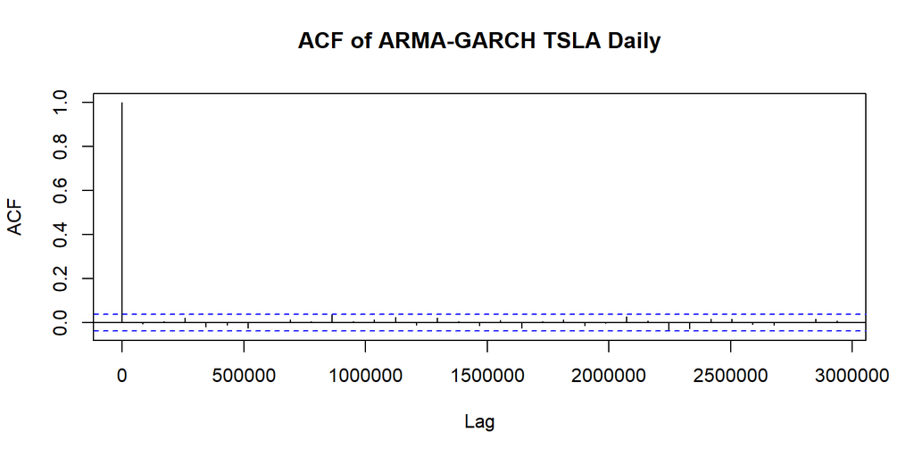

```r
#daily final.model.Daily = garchFit(~ arma(0,1)+ garch(1,1), train.dailyR, trace = FALSE)
porder_Daily=0;qorder_Daily=1
resids_arma_garch = residuals(final.model.Daily)
squared.resids.arma.garch = resids_arma_garch^2
acf(resids_arma_garch, main="ACF of ARMA-GARCH TSLA Daily")
```

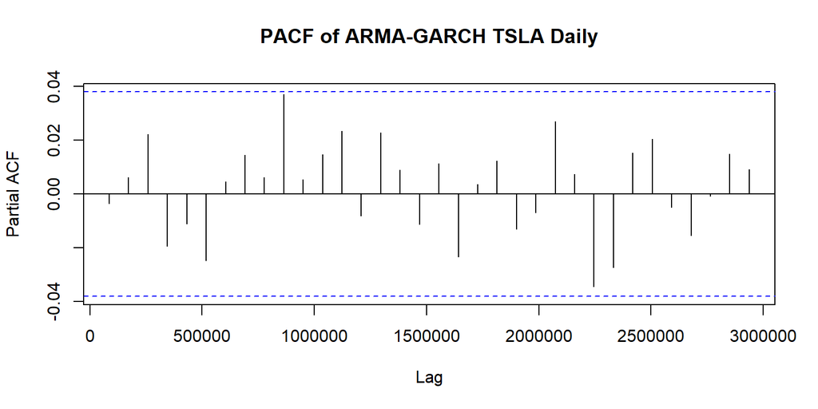

```r
pacf(resids_arma_garch, main="PACF of ARMA-GARCH TSLA Daily")
```

```r
Box.test(resids_arma_garch, lag = (porder_Daily+qorder_Daily+1), type = "Ljung-Box", fitdf = (porder_Daily+qorder_Daily))
```

```
##
##  Box-Ljung test
##
## data:  resids_arma_garch
## X-squared = 0.1347, df = 1, p-value = 0.7136
```

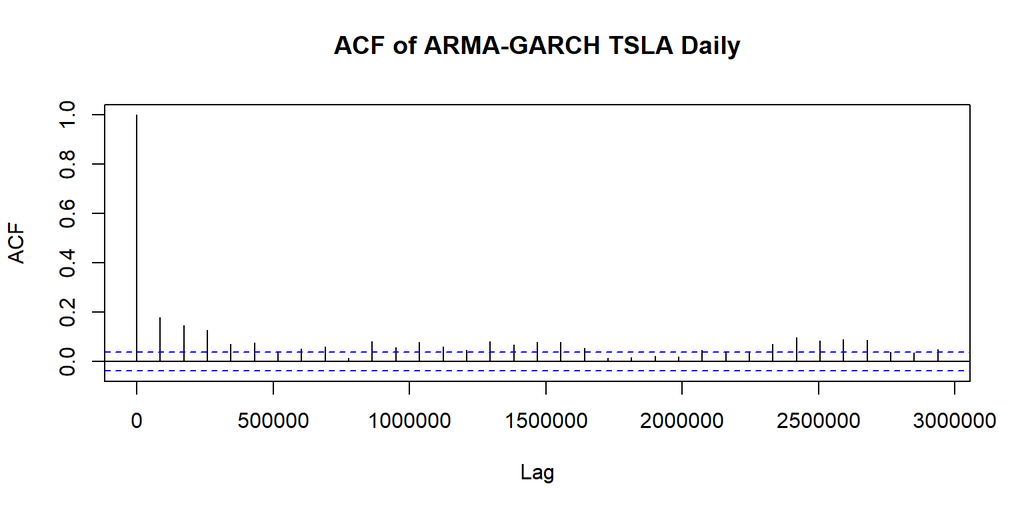

```r
acf(squared.resids.arma.garch, main="ACF of ARMA-GARCH TSLA Daily")
```

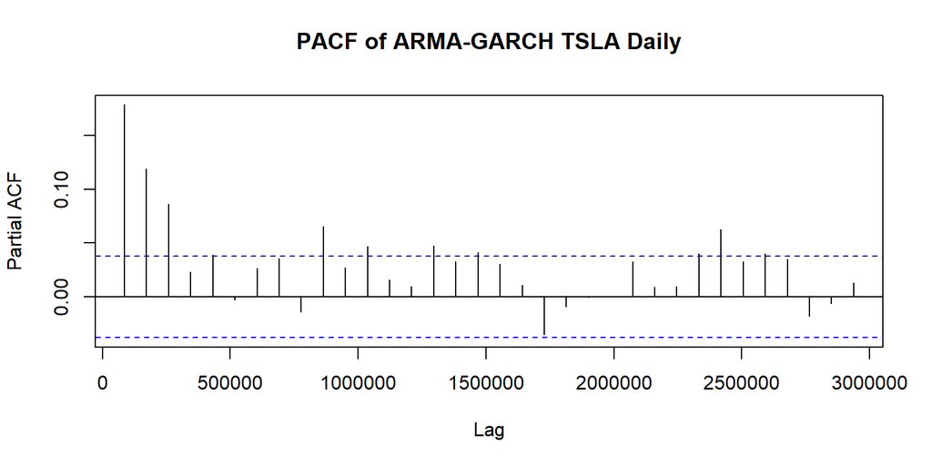

```r
pacf(squared.resids.arma.garch, main="PACF of ARMA-GARCH TSLA Daily")
```

```r
Box.test(squared.resids.arma.garch, lag = (porder_Daily+qorder_Daily+1), type = "Ljung-Box", fitdf = (porder_Daily+qorder_Daily))
```

```
##
##  Box-Ljung test
##
## data:  squared.resids.arma.garch
## X-squared = 142.73, df = 1, p-value < 2.2e-16
```

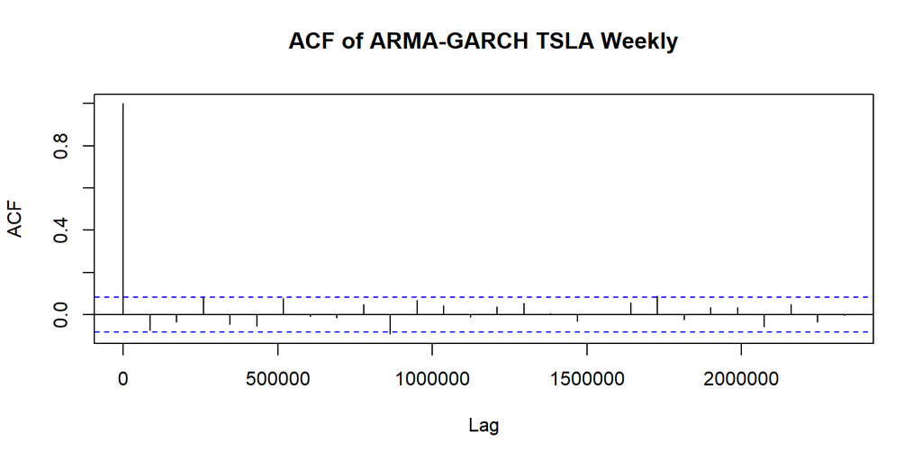

```r
#WEEKLY  final.model.Weekly = garchFit(~ arma(4,2)+ garch(1,1), tainW, trace = FALSE)
porder_Weekly=4;qorder_Weekly=2
resids_arma_garch2 = residuals(final.model.Weekly)
squared.resids.arma.garch2 = resids_arma_garch2^2
acf(resids_arma_garch2, main="ACF of ARMA-GARCH TSLA Weekly")
```

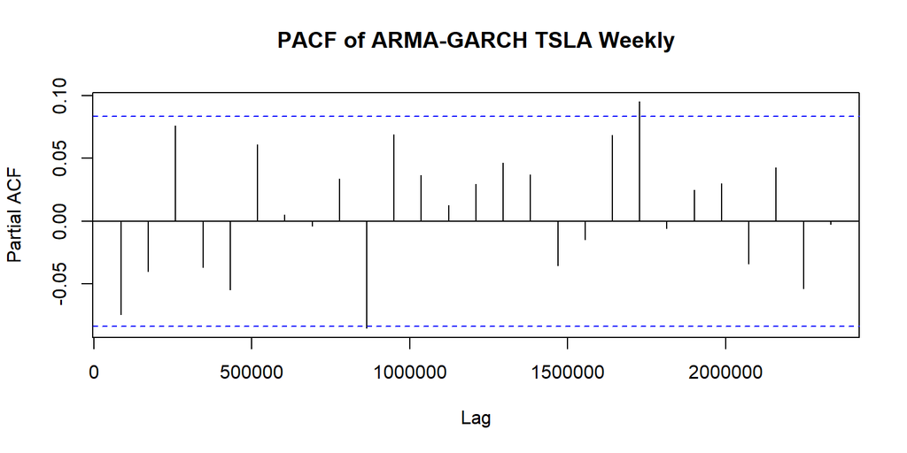

```r
pacf(resids_arma_garch2, main="PACF of ARMA-GARCH TSLA Weekly")
```

```r
Box.test(resids_arma_garch2, lag = (porder_Weekly+qorder_Weekly+1), type = "Ljung-Box", fitdf = (porder_Weekly+qorder_Weekly))
```

```
##
##  Box-Ljung test
##
## data:  resids_arma_garch2
## X-squared = 13.386, df = 1, p-value = 0.0002535
```

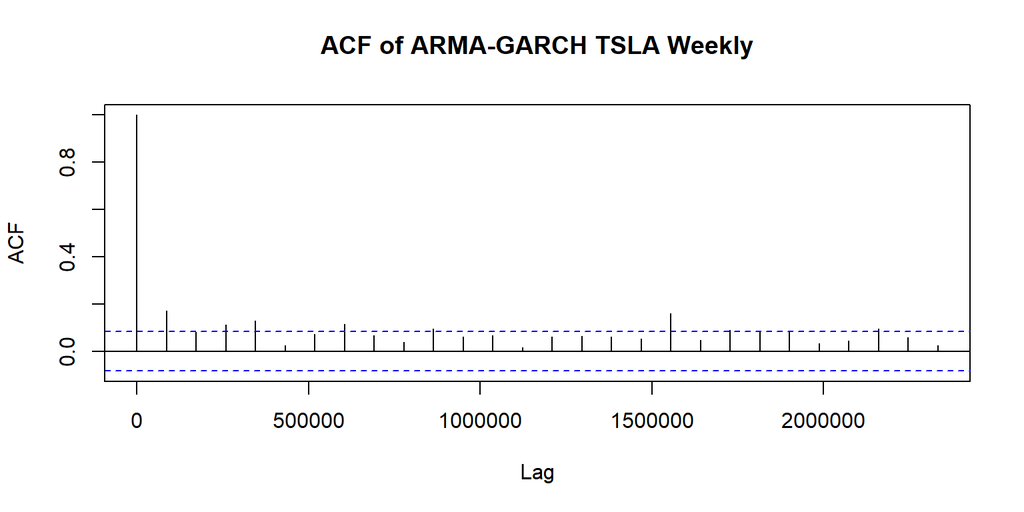

```r
acf(squared.resids.arma.garch2, main="ACF of ARMA-GARCH TSLA Weekly")
```

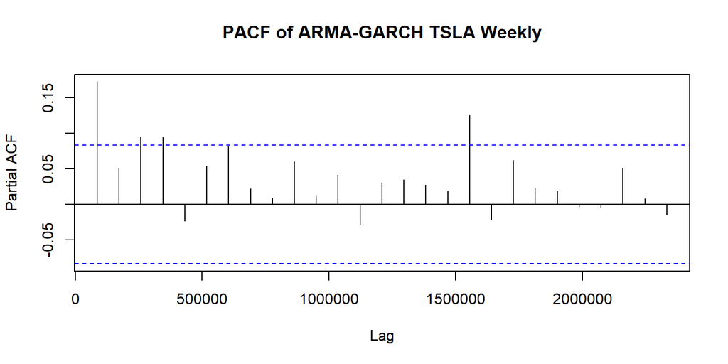

```r
pacf(squared.resids.arma.garch2, main="PACF of ARMA-GARCH TSLA Weekly")
```

```r
Box.test(squared.resids.arma.garch2, lag = (porder_Weekly+qorder_Weekly+1), type = "Ljung-Box", fitdf = (porder_Weekly+qorder_Weekly))
```

```
##
##  Box-Ljung test
##
## data:  squared.resids.arma.garch2
## X-squared = 47.011, df = 1, p-value = 7.059e-12
```

*Response:ARMA GARCH residual analysis for the Weekly and daily Data*

The box test for residual DAILY Tesla price model (AMRA(0,1)-GARCH(1,1) )show p>0.05, we failed to reject the null hypothesis and conclude that the data values are independent. The squared daily residuals has a small p value, rejecting the null hypothesis that the time series isn’t auto correlated.

The box test of weekly model (ARMA(4,2)-GARCH(1,1))show p<0.05, so does the squared weekly residuals. Also ACF and PACF of squared weekly &daily residuals do not resemble the white noises, suggesting a higher order GARCH model may be considered.

**3c.** Apply the model identified in (3a) and forecast the mean and the variance of the last week of data. Plot the predicted data to compare the predicted values to the actual observed ones. Include 95% confidence intervals for the forecasts in the corresponding plots. Interpret the results, particularly comparing forecast using daily versus weekly data.

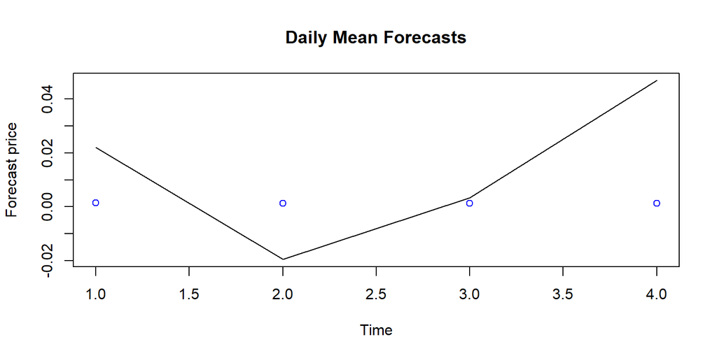

```r
#daily
n=length(daily_ret_ts)
n_forward=4
nfit=n-n_forward
train.dailyR=daily_ret_ts[1:nfit]
test.dailyR=daily_ret_ts[(nfit+1):n]
spec.1 = ugarchspec(variance.model=list(garchOrder=c(1,1)),mean.model=list(armaOrder=c(0, 1), include.mean=T),distribution.model="std")

    nfore = length(test.dailyR)
        fore.series.1 = NULL
        fore.sigma.1 = NULL

        for(f in 1: nfore)
        {
            #Fit models
            data = train.dailyR
            if(f>=2)
            data = c(train.dailyR,test.dailyR[1:(f-1)])
            final.model.1 = ugarchfit(spec.1, data, solver = 'hybrid')

            #Forecast
            fore = ugarchforecast(final.model.1, n.ahead=4)
            fore.series.1 = c(fore.series.1, fore@forecast$seriesFor)
            fore.sigma.1 = c(fore.sigma.1, fore@forecast$sigmaFor)

        }
        fore.series.1[is.nan(fore.series.1)]=0
#DAILY MEAN FORCAST
ts.plot(test.dailyR,main='Daily Mean Forecasts',ylab='Forecast price')
points(fore.series.1,col="blue")
```

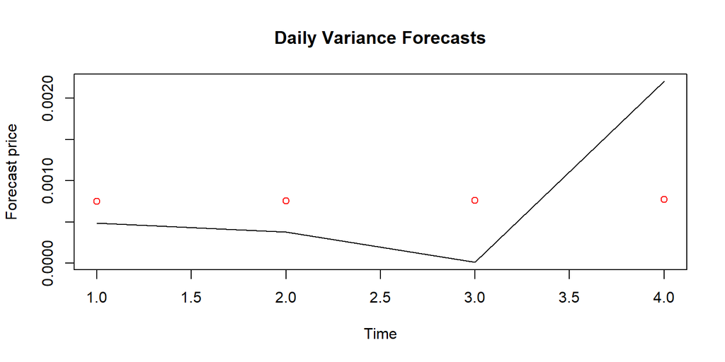

```r
#DAILY VARIANCE FORCAST
ts.plot(test.dailyR^2,main='Daily Variance Forecasts',ylab='Forecast price')
points(fore.sigma.1^2,col="red")
```

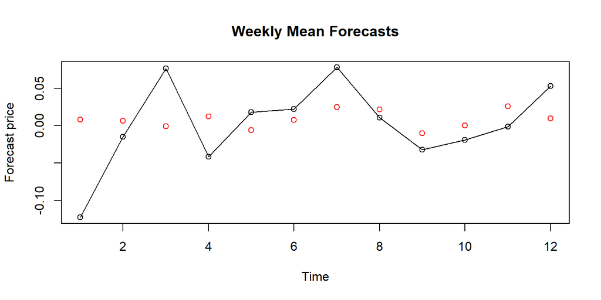

```r
#weekly
TSLAWeekly <- ts(weeklydata$Adj.Close,start=c(2011,1,1),freq=52)
weekly <- index(TSLAWeekly)

library(fGarch)
n=length(weekly_ret_ts)
n_forward=1
nfit=n-n_forward
train.weeklyR=weekly_ret_ts[1:nfit]
test.weeklyR=weekly_ret_ts[540:551]
spec.2 = ugarchspec(variance.model=list(garchOrder=c(1,1)),mean.model=list(armaOrder=c(4, 2), include.mean=T),distribution.model="std")
final.model.2 = garchFit(~ arma(4,2)+ garch(1,1), data=train.weeklyR, trace = FALSE)
     nfore = length(test.weeklyR)
        fore.series.2 = NULL
        fore.sigma.2 = NULL

        for(f in 1: nfore)
        {
            #Fit models
            data = train.weeklyR
            if(f>=2)
            data = c(train.weeklyR,test.weeklyR[1:(f-1)])
            final.model.2 = ugarchfit(spec.2, data, solver = 'hybrid')

            #Forecast
            fore = ugarchforecast(final.model.2, n.ahead=1)
            fore.series.2 = c(fore.series.2, fore@forecast$seriesFor)
            fore.sigma.2 = c(fore.sigma.2, fore@forecast$sigmaFor)

        }
        fore.series.2[is.nan(fore.series.2)]=0

#WEEKLY MEAN FORCAST
ts.plot(test.weeklyR,main='Weekly Mean Forecasts',ylab='Forecast price',type="o")
points(fore.series.2,col="red")
```

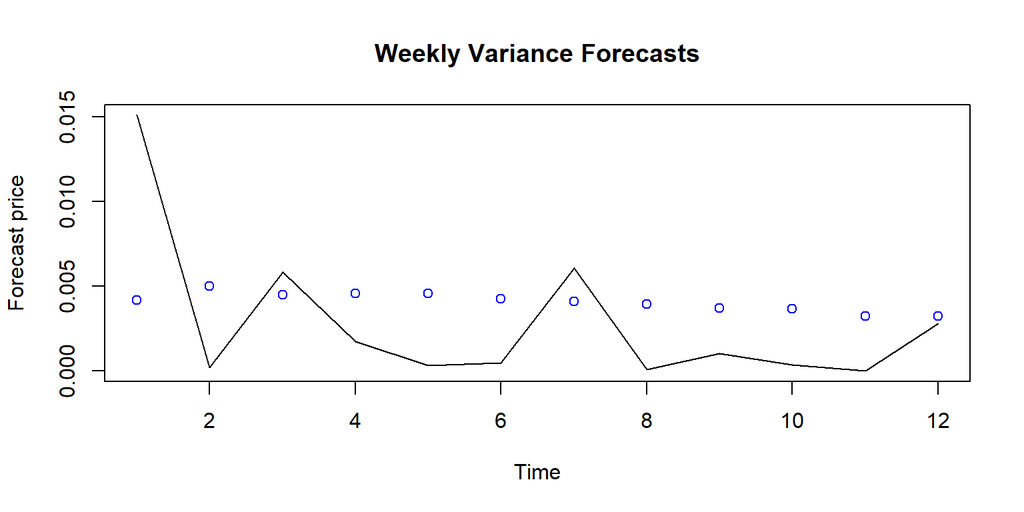

```r
#WEEKLY VARIANCE FORCAST
ts.plot(test.weeklyR^2,main='Weekly Variance Forecasts',ylab='Forecast price')
points(fore.sigma.2^2,col="blue")
```

*Response: Interpretation of the results* The predictions for the daily conditional mean are close to the zero line, not capturing variations as we observed in the existing data. Compared to the daily mean, the weekly mean varies a little bit more towards the trend of the observed data; henCe captures the mean better. In the results of variance, we see the daily data is close to a horizon line - very little variance, while the weekly variance shows variance with a decreasing trend. Overall, this shows the weekly model is a better forecasting model compared to the daily one, and the forecasting is a combination of mean and variance.

**3d.** Calculate Mean Absolute Percentage Error (MAPE) and Precision Measure (PM) for the mean forecasts. Compare the accuracy of the predictions for the daily and weekly time series using these two measures. Compare the accuracy of the forecasts with those obtained in (2d). Interpret the results.

```r
n=length(daily_ret_ts)
n_forward=4
nfit=n-n_forward
train.dailyR=daily_ret_ts[1:nfit]
test.dailyR=daily_ret_ts[(nfit+1):n]
#daily
pred_daily = as.vector(fore.series.1)
true_daily = as.vector(test.dailyR)
mean(abs(pred_daily-true_daily)/abs(true_daily))
```

```
## [1] 0.8936271
```

```r
sum((pred_daily-true_daily)^2)/sum((true_daily-mean(true_daily))^2)
```

```
## [1] 4.943078
```

```r
TSLAWeekly <- ts(weeklydata$Adj.Close,start=c(2011,1,1),freq=52)
weekly <- index(TSLAWeekly)

library(fGarch)
n=length(weekly_ret_ts)
n_forward=1
nfit=n-n_forward
train.weeklyR=weekly_ret_ts[1:nfit]
test.weeklyR=weekly_ret_ts[(nfit+1):n]
#weekly
pred_weekly = as.vector(fore.series.2)
true_weekly = as.vector(test.weeklyR)
mean(abs(pred_weekly-true_weekly)/abs(true_weekly))
```

```
## [1] 0.845155
```

```r
sum((pred_weekly-true_weekly)^2)/sum(true_weekly-mean(true_weekly))
```

```
## [1] Inf
```

*Response: Model comparison* The MAPE of weekly model is lower than the daily model showing more accuracy in price prediction. We are unable to check the weekly PM since we are only predicting one point for weekly data.

#Question 4: Reflection on the Modeling and Forecasting (10 points)

Based on the analysis above, discuss the application of ARIMA on the stock price versus the application of ARMA-GARCH on the stock return. How do the model fit the data? How well do the model predict? How do the models perform when using daily versus weekly data? Would you use one approach over another for different settings? What are some specific points of caution one would need to consider when applying those models?

*Response: Final considerations* The ARIMA model assumes the constant variance and ARMA-GARCH model can model the non constant variance. When it comes to the stock analysis, volatility is one of the major factors to predict the future trends hence a model that factors in the consonant variance is usually more appropriate to forecast the trend.

In this example, daily ARIMA(8,1,7) and weekly ARIMA(8,2,8) ignores the variance effect hence underestimated the data. The daily ARMA(0,1)-GARCH(1,1) and weekly ARMA(4,2)-GARCH(1,1) captures the volatility better but higher GARCH may be considered. When comparing the daily vs weekly data performance, overall I see a better performance in weekly data in both models. This is because ARIMA model ignores variance, it can be used to predict very short term data and as effective as ARMA-GARCH; since we are simply looking at one week data, the performance of ARIMA is not significantly worse than ARMA-GARCH. Depending on the predicting time period, the type of the stocks, I would use different approach over another. As stated, ARIMA can be computational less expensive hence when making a short-term price prediction on a stable stock price with no huge volatility, I would consider ARIMA model; otherwise, I could use a joint model to capture variance. To sum, there are a couple specific points when considering selecting models to predict stock price: 1） Time horizon; 2) volatility; 3) mean; 4) computational expensive or not; 5) prediction accuracy.